# Actividad de grupo, regresiones. ¿Qué modelo explica mejor el crimen en US?

Norberto Asensio

09/10/2023

[figure not shown]

## Contextualización, base de datos e instrucciones generales

El comportamiento delictivo es el resultado de combinaciones complejas de variables que crean situaciones que hacen que las personas cometan tales delitos (Horney, 2006).

Horney, J. (2006). An alternate psychology of criminal behavior. The American Society of Criminology 2005 Presidential Address, 44, 1.

Exploremos esta teoría utilizando datos. Lo primero, repasa la teoría y tus apuntes sobre regresiones lineales en clase y los ejercicios correspondientes antes de empezar este ejercicio, todo va a ser más sencillo de esa manera. Si no has tocado la teoría o los ejercicios tendrás problemas para sacar el mejor partido de este ejercicio, estarás trabajando con muy poco sentido. Mi consejo es que hagas todos los ejercicios antes y no intentes hacerlo sobre la marcha, dedicale tiempo primero a entender la teoría y como se consigue la información necesaria en R para el análisis.

La base de datos para este ejercicio, `Mcdaniel.csv`, se ha obtenido de esta publicación:

Mcdaniel, M. A. (2006). Estimating state IQ: Measurement challenges and preliminary correlates. Intelligence, 34(6), 607–619. doi: 10.1016/j.intell.2006.08.007

Utiliza esta base datos para crear diferentes análisis de regresión lineal (pueden ser múltiples y simples) y encuentra el modelo que mejor explique las tasas de delincuencia en una muestra de 44 estados de US.

Leemos los datos y los guardamos como **crimen.data**

```r
crimen.data<-read.csv("Mcdaniel.csv")
str(crimen.data)
```

```
## 'data.frame':    44 obs. of  7 variables:
##  $ state : chr  "Alabama" "Alaska" "Arizona" "Arkansas" ...
##  $ IQ    : num  95.7 99 97.4 97.5 95.5 ...
##  $ white : num  9.5 6.1 11 6.8 10.6 6.2 7.4 12.2 8 2 ...
##  $ GPS   : num  2.8 4.7 3.2 2.7 4 4.1 4.9 3.2 3.6 2.9 ...
##  $ health: num  -11.9 -0.8 -1.1 -14.3 4.9 12.5 15.6 -9.9 -9.5 8.6 ...
##  $ effect: num  1.3 3.3 4.3 3 2.7 4 3 4.7 5 4.3 ...
##  $ crime : num  0.4 0.6 0.5 0.5 0.6 0.4 0.3 0.7 0.5 0.2 ...
```

```r
head(crimen.data,10)
```

```
##          state    IQ white GPS health effect crime
## 1      Alabama  95.7   9.5 2.8  -11.9    1.3   0.4
## 2       Alaska  99.0   6.1 4.7   -0.8    3.3   0.6
## 3      Arizona  97.4  11.0 3.2   -1.1    4.3   0.5
## 4     Arkansas  97.5   6.8 2.7  -14.3    3.0   0.5
## 5   California  95.5  10.6 4.0    4.9    2.7   0.6
## 6     Colorado 101.6   6.2 4.1   12.5    4.0   0.4
## 7  Connecticut 103.1   7.4 4.9   15.6    3.0   0.3
## 8      Florida  98.4  12.2 3.2   -9.9    4.7   0.7
## 9      Georgia  98.0   8.0 3.6   -9.5    5.0   0.5
## 10       Idaho 101.4   2.0 2.9    8.6    4.3   0.2
```

Las variables de la base de datos (de acuerdo a los autores de la base de datos):

**state**: Estado de US

**IQ**: Puntaje medio estimado del IQ (coeficiente intelectual) del estado. El coeficiente intelectual del estado se estimó a partir de las pruebas estandarizadas de la Evaluación Nacional del Progreso Educativo (NAEP) para lectura y matemáticas que se administran a una muestra de niños de escuelas públicas en cada uno de los 50 estados.

**white**: Porcentaje de personas blancas en la educación privada. Algunos niños no asisten a las escuelas públicas, pueden ser educados en casa, pueden tener tutores privados o pueden asistir a escuelas privadas. La mayoría de las escuelas privadas requieren que los padres del niño paguen la matrícula y las cuotas, a diferencia de las escuelas públicas, que son financiadas por el gobierno.

**GPS**: Producto estatal bruto (similar al “producto interior bruto”). Como medida de la productividad estatal, se utilizó el producto estatal bruto total per cápita promediado entre los años 2000 y 2004. El producto estatal bruto es dado por el Departamento de Comercio de EE. UU. (2006). Para calcular la versión per cápita de esta variable, se dividió por la población del estado según lo informado en los datos del censo.

**health**: Puntaje de salud. Medida de la salud del estado, los puntajes de salud del estado se promediaron para los años 2002 a 2005, según lo informado por United Health Foundation (2006). Esta medida de salud es un agregado de varios índices de la salud de los residentes de los estados.

**effect**: Puntaje de eficacia del gobierno estatal. El Government Performance Project (2006) es una organización con financiación privada que evalúa la eficacia de los gobiernos estatales en varias áreas. Los datos están disponibles para 1991, 2001 y 2005. La efectividad del gobierno se define en este estudio como la media de la calificación de efectividad general para los 3 años.

**Crime**: Crimen violento. Esta medida se extrae de la Oficina de Estadísticas de Justicia (2006) y reporta crímenes violentos por cada mil personas. Es la media de los años 2002 a 2004.

## Seleccionando el mejor modelo

Para seleccionar el mejor modelo que explique la tasa de crimenes en los estados, vais a utilizar una estrategia llamada regresión escalonada (“stepwise regression”), que consiste en agregar y eliminar predictores de forma interactiva, y así encontrar el modelo más parsimonioso según la mayor R cuadrado ajustada (**ajusted R-squared** = coeficiente de determinación = tamaño del efecto de la regresión). Es decir, vamos a probar activamente diferentes combinaciones que produzcan un buen modelo con el R cuadrado ajustado más alto posible (un tamaño de efecto grande) que además sea significativo. Puedes empezar de menos a más (es decir, de modelos simples a modelos múltiples más complejos añadiendo predictores) o de más a menos (es decir, del modelo completo con todas la variables, para ir quitando y poniendo variables, hasta llegar a modelo simples con una sola variable).

```r
modeloI<-lm(crime~IQ+white,data=crimen.data)#un predictor
modeloIP<-lm(crime~IQ+GPS,data=crimen.data)#dos predictores
modelo.IPG<-lm(crime~IQ+white+GPS,data=crimen.data)#3 predictores
```

Calculemos el tamaño del efecto (R cuadrado ajustado) para cada modelo hasta ahora

```r
summary(modeloI)$adj.r.squared
```

```
## [1] 0.6482635
```

```r
summary(modeloIP)$adj.r.squared
```

```
## [1] 0.561913
```

```r
summary(modelo.IPG)$adj.r.squared
```

```
## [1] 0.6773613
```

De acuerdo a los R cuadrado ajustados, el mejor modelo entre los que se han presentado sería el **modelo.IPG**.

Sin embargo, recuerda que un supuesto importante de la regresión múltiple es que los predictores del mismo modelo no pueden correlacionarse (**supuesto de multicolinealidad**). Tenemos que verificar esto antes de seguir adelante y quedarnos con este modelo.

## Manera 1: a priori para verificar el supuesto the autocorrelación,

En nuesro **modelo.IPG** NO debería existir una correlación muy fuerte (r > 0.6, pongo un umbral bastante conservador solo para este ejercicio) entre IQ y white, entre GPS y White, y entre GPS y IQ. Para ver esto rápidamente podemos visualizar todas las correlaciones entre predictores simultaneamente usando la libreria `corrplot`.

```r
library(corrplot)
```

Bien, ahora para facilitar la matriz de correlaciones voy a no considerar la variable `state`, ya que no solo no está entre mis predictores, sino que es una variable nominal (no tiene sentido hacer una correlación númerica con una lista de nombres):

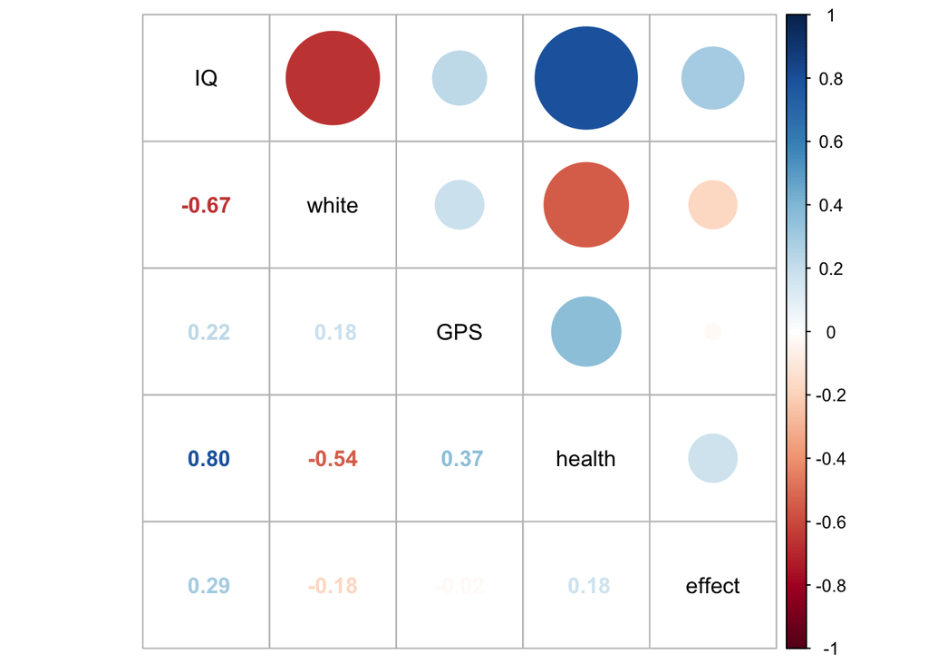

```r
num.variables<-crimen.data[,c(2,3,4,5,6)]#solo queremos las columnas de 2 a 7 (nuestros predictores)
matrix<-cor(num.variables,use="complete.obs")#calcula todas las correlaciones simultaneamente y guardalas en matrix
corrplot.mixed(matrix,
               lower = "number",
               upper = "circle",
               tl.col = "black")#dibujalas
```

## Manera 2: a posteriori para verificar el supuesto the autocorrelación,

[figure not shown]

Este modo te dará mayor libertad de posibles módelos. Para una variable predictora determinada, la multicolinealidad se puede evaluar calculando una puntuación denominada factor de inflación de la varianza (VIF: “variance inflate factor”), que mide cuánto se “infla” la varianza de un coeficiente de regresión debido a la multicolinealidad en el modelo. R se puede calcular manualmente como `1 / (1 – R Square)`. Por lo tanto, el menor valor posible de VIF para un predictor es uno (ausencia de multicolinealidad). Como regla general, un valor de VIF entre dos 2 y 5 indica una correlación moderada entre una variable predictora dada y otras variables predictoras en el modelo. Un valor superior a 5 indica una correlación severa entre una variable predictora dada y otras variables predictoras en el modelo (James et al. 2014). Esta es una decisión cualitativa tomada por los investigadores, depende de que tan rigurosos quieran ser. En este ejercicio, si se decide usar el modo VIF para determinar la autocorrelación de las variables en cada modelo, vamos a poner **la regla de VIF > 3** para decidir si hay problemas de correlación en una variable. Esto lo hacemos por razones pedagógicas ya que de esta manera se podrá “jugar” con más modelos diferentes que puedan explicar crimen.

James, Gareth, Daniela Witten, Trevor Hastie, and Robert Tibshirani. 2014. An Introduction to Statistical Learning: With Applications in R. Springer Publishing Company, Incorporated.

La biblioteca `car` contiene el comando `vif()`, que calcula el valor VIF de cada variable predictora de un modelo particular simplemente pasándolo por el modelo, de esta manera no tendrá que hacerse manualmente. Recuerda que tendrás que instalarla antes usando `install.packages("car")` antes de activarla:

```r
library(car)#activa la libreria
```

calcula los VIFs de cada predictor del modelo **modelo.IPG** usando `vif()`:

```r
vif(modelo.IPG)
```

```
##       IQ    white      GPS
## 2.293550 2.253870 1.321318
```

Podríamos incluso dibujar los VIF por variable en el modelo (esto es más util cuando son muchos predictores):

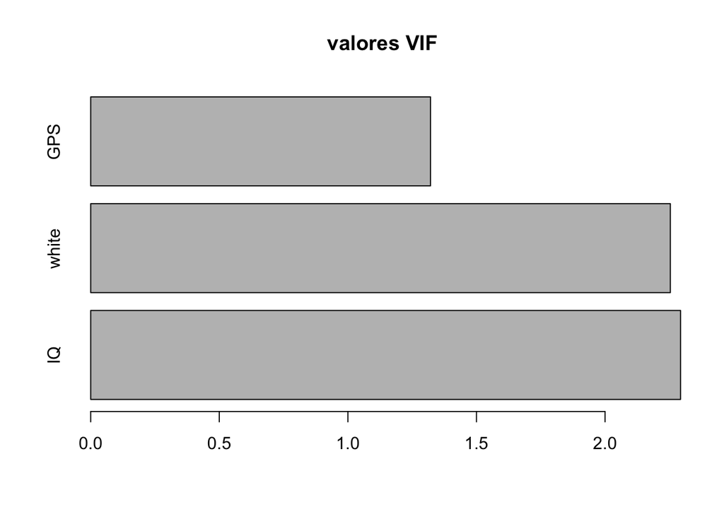

```r
vif_values <- vif(modelo.IPG)#vector de valores
barplot(vif_values, main = "valores VIF", horiz = T)#grafico de barras con vif para cada parametro
abline(v = 3, lwd = 3, lty = 2)#poner el limite en 3, no aparece porque ninguno se pasa
```

Como hemos estamos considerando VIF > 3 para tener una autocorrelación severa, las tres variables predictoras pueden estar en el mismo modelo en este caso, esto es, su VIF no es lo suficientemente grande para causar problemas. Por lo tanto, el modelo pasaría el supuesto de falta de multicolinearidad.

## Vuestro turno

Continua ejecutando modelos de regresión simple y múltiple (**intenta al menos 10 combinaciones**) para predecir crimen y selecciona el modelo que juzgues más apropiado teniendo en cuenta no solo el **R cuadrado ajustado** más alto, sino también que no debe existir poblemas de autocorrelación entre los predictores de un mismo modelo (elige el modo arriba, 1 o 2, que quieras para tomar está decisión). Así mismo, **no olvideis validar el modelo final inspeccionando gráficamente los residuos de la regresión pasando el comando `plot()` al modelo de interés**. También es necesario que **dibujeis el modelo de la manera más ilustrativa posible**, si son 3 o más predictores es posible que sea mejor dibujar el efecto de cada predictor independientemente en diferentes figuras (una por predictor), si son dos aún es posible dibujarlos en una sola gráfica o utilizar un plano. Tres o más predictores en un modelo puede ser demasiado confuso para ponerlas en un solo diagrama de dispersión y puede ser mejor utilizar un gráfico con la nube de puntos y su curva de regresion por cada predictor del modelo. Aún así, dependiendo de la escala de los predictores puede que la gráfica sea muy extraña y que algunos líneas de regresión no aparezca debido a que algunas escalas son más grande que otras (considerar estandarizar los predictores en ese caso). Una vez seleccionado el modelo final que explica crimen, **haced una interpretación estadística adecuada del mismo**. Como nota, entiende que tal vez el mejor modelo no sea una regresión multiple, si no que quizás sea una regressión simple con un solo predictor, pero explora las posibilidades antes de tomar esa decisión. Es posible también que un modelo sea significativo pero no todos sus predictores (es decir sus pendientes).

[figure not shown]

Image source: https://dribbble.com